Skip to main content

# Publication figure report

Author

Affiliation

none

manual

**Important**

A manual command generated this report without an LLM model. No separate human scientific review is part of this fixed recipe. The report records the selected recipe and does not claim a new method.

## Figure

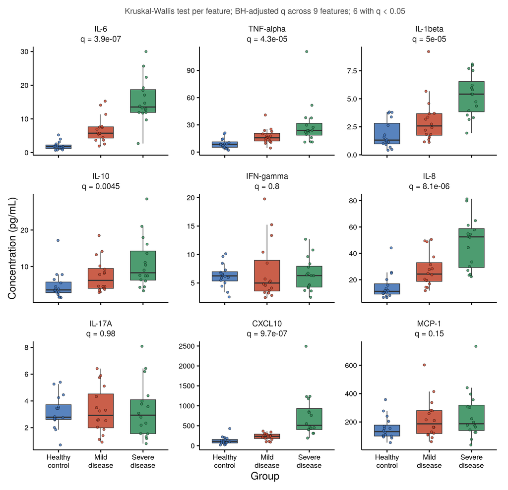

Publication figure

## Statistical results

| feature | test | statistic | df1 | df2 | p_value | p_adj | p_adj_signif | effect_size | effect_size_name | note | n_Healthy control | n_Mild disease | n_Severe disease |
| --- | --- | --- | --- | --- | --- | --- | --- | --- | --- | --- | --- | --- | --- |
| IL-6 | Kruskal-Wallis test | 33.894059056614 | 2 |  | 4.36514416241489e-08 | 3.9286297461734e-07 | **** | 0.708756867924756 | eta-squared (H) |  | 16 | 16 | 16 |
| TNF-alpha | Kruskal-Wallis test | 21.728379607013 | 2 |  | 1.91312046732669e-05 | 4.30452105148505e-05 | **** | 0.4384084357114 | eta-squared (H) |  | 16 | 16 | 16 |
| IL-1beta | Kruskal-Wallis test | 20.9866071428571 | 2 |  | 2.77214639932302e-05 | 4.98986351878143e-05 | **** | 0.421924603174603 | eta-squared (H) |  | 16 | 16 | 16 |
| IL-10 | Kruskal-Wallis test | 11.6114401834663 | 2 |  | 0.00301028629016358 | 0.00451542943524536 | ** | 0.213587559632585 | eta-squared (H) |  | 16 | 16 | 16 |
| IFN-gamma | Kruskal-Wallis test | 0.677811024263157 | 2 |  | 0.712549773217701 | 0.801618494869913 | ns | -0.0293819772385965 | eta-squared (H) |  | 16 | 16 | 16 |
| IL-8 | Kruskal-Wallis test | 25.6422193877551 | 2 |  | 2.70310432914328e-06 | 8.10931298742983e-06 | **** | 0.525382653061224 | eta-squared (H) |  | 16 | 16 | 16 |
| IL-17A | Kruskal-Wallis test | 0.0401807523204812 | 2 |  | 0.980110090717326 | 0.980110090717326 | ns | -0.0435515388373226 | eta-squared (H) |  | 16 | 16 | 16 |
| CXCL10 | Kruskal-Wallis test | 30.6906887755102 | 2 |  | 2.16571652082853e-07 | 9.74572434372838e-07 | **** | 0.637570861678005 | eta-squared (H) |  | 16 | 16 | 16 |
| MCP-1 | Kruskal-Wallis test | 4.30357142857142 | 2 |  | 0.116276335959318 | 0.149498146233409 | ns | 0.0511904761904759 | eta-squared (H) |  | 16 | 16 | 16 |

## Methods

Concentration (pg/mL) was compared between the levels of group (Healthy control, Mild disease, Severe disease) separately for each of 9 features. One test family was chosen for the whole panel: the Shapiro-Wilk test was run on each of the 27 feature-by-group samples, and because 15 of them departed from normality (P <= 0.05, or fewer than 3 values) the rank-based Kruskal-Wallis test was used for every feature. P values were adjusted across the 9 features with the Benjamini-Hochberg method; 6 features had an adjusted P (q) below 0.05. The effect size is eta-squared (H). Group sizes per feature: Healthy control (n = 16), Mild disease (n = 16), Severe disease (n = 16). Drawn in R 4.4.1 with ggplot2 3.5.1.

## Plot configuration

The complete plot configuration is in `plot_config.yaml`.

## Provenance

| field | value |
| --- | --- |
| repository | pubready |
| repository_version | 4.0.0 |
| git_commit | 567ce8900bdb5db88369d131c8d787b042b3af57 |
| git_dirty | FALSE |
| llm_provider | none |
| llm_model | none |
| agent_harness | manual |
| agent_harness_version | not_recorded |
| container_image | localhost/pubready:4.0.0 |
| container_digest | sha256:0f57027a3fbca5ec9d41d74ca91226fbdf45d94b1a85f271637d12733db5d483 |
| input | {“file”:“input_cytokine_panel.csv”,“md5”:“f77a1f672f5ed66b30e6a03fd7e90698”,“sha256”:“4ccf271257662e1dee4339f1d69d6d74ce5bd3f47078a5fde1a0aed9bdca004d”} |
| command | figkit plot –recipe feature_panel |
| analysis_options | {“engine”:“r”,“recipe”:“feature_panel”,“data”:{“file”:“cytokine_panel.csv”,“x”:“group”,“y”:“concentration_pg_ml”,“fill”:null,“facet”:“cytokine”,“time”:null,“event”:null,“annotation”:null,“id”:null,“gr… |
| random_seeds | not_applicable |
| session_record | session_info.txt |
| created_utc | 2026-07-18T00:00:00Z |
| review_state | not_applicable |
| reviewer | none |
| quarto_version | 1.11.4 |

The report source reads only files in this bundle.